# Homework 8

Joyce

2025-02-10

## Instructions

Answer the following questions and complete the exercises in RMarkdown. Please embed all of your code and push your final work to your repository. Your final lab report should be organized, clean, and run free from errors. Remember, you must remove the `#` for the included code chunks to run. Be sure to add your name to the author header above.

Make sure to use the formatting conventions of RMarkdown to make your report neat and clean!

## Load the libraries

```r
library(tidyverse)
library(janitor)
library(skimr)
library(naniar)
```

## Data

**1. For this homework, we will use two different data sets. Please load `amniota` and `amphibio`.**

`amniota` data:  
Myhrvold N, Baldridge E, Chan B, Sivam D, Freeman DL, Ernest SKM (2015). “An amniote life-history database to perform comparative analyses with birds, mammals, and reptiles.” *Ecology*, *96*, 3109. doi: 10.1890/15-0846.1 (URL: https://doi.org/10.1890/15-0846.1).

```r
amniota <- read_csv("data/amniota.csv") %>% clean_names()
amniota
```

```
## # A tibble: 21,322 × 36
##    class order     family genus species subspecies common_name female_maturity_d
##    <chr> <chr>     <chr>  <chr> <chr>        <dbl> <chr>                   <dbl>
##  1 Aves  Accipitr… Accip… Acci… albogu…       -999 Pied Gosha…             -999
##  2 Aves  Accipitr… Accip… Acci… badius        -999 Shikra                   363.
##  3 Aves  Accipitr… Accip… Acci… bicolor       -999 Bicolored …             -999
##  4 Aves  Accipitr… Accip… Acci… brachy…       -999 New Britai…             -999
##  5 Aves  Accipitr… Accip… Acci… brevip…       -999 Levant Spa…              363.
##  6 Aves  Accipitr… Accip… Acci… castan…       -999 Chestnut-f…             -999
##  7 Aves  Accipitr… Accip… Acci… chilen…       -999 Chilean Ha…             -999
##  8 Aves  Accipitr… Accip… Acci… chiono…       -999 White-brea…              548.
##  9 Aves  Accipitr… Accip… Acci… cirroc…       -999 Collared S…             -999
## 10 Aves  Accipitr… Accip… Acci… cooper…       -999 Cooper's H…              730
## # ℹ 21,312 more rows
## # ℹ 28 more variables: litter_or_clutch_size_n <dbl>,
## #   litters_or_clutches_per_y <dbl>, adult_body_mass_g <dbl>,
## #   maximum_longevity_y <dbl>, gestation_d <dbl>, weaning_d <dbl>,
## #   birth_or_hatching_weight_g <dbl>, weaning_weight_g <dbl>, egg_mass_g <dbl>,
## #   incubation_d <dbl>, fledging_age_d <dbl>, longevity_y <dbl>,
## #   male_maturity_d <dbl>, inter_litter_or_interbirth_interval_y <dbl>, …
```

`amphibio` data:  
Oliveira BF, São-Pedro VA, Santos-Barrera G, Penone C, Costa GC (2017). “AmphiBIO, a global database for amphibian ecological traits.” *Scientific Data*, *4*, 170123. doi: 10.1038/sdata.2017.123 (URL: https://doi.org/10.1038/sdata.2017.123).

```r
amphibio <- read_csv("data/amphibio.csv") %>% clean_names()
amphibio
```

```
## # A tibble: 6,776 × 38
##    id    order family genus species   fos   ter   aqu   arb leaves flowers seeds
##    <chr> <chr> <chr>  <chr> <chr>   <dbl> <dbl> <dbl> <dbl>  <dbl>   <dbl> <dbl>
##  1 Anf0… Anura Allop… Allo… Alloph…    NA     1     1     1     NA      NA    NA
##  2 Anf0… Anura Alyti… Alyt… Alytes…    NA     1     1     1     NA      NA    NA
##  3 Anf0… Anura Alyti… Alyt… Alytes…    NA     1     1     1     NA      NA    NA
##  4 Anf0… Anura Alyti… Alyt… Alytes…    NA     1     1     1     NA      NA    NA
##  5 Anf0… Anura Alyti… Alyt… Alytes…    NA     1    NA     1     NA      NA    NA
##  6 Anf0… Anura Alyti… Alyt… Alytes…     1     1     1     1     NA      NA    NA
##  7 Anf0… Anura Alyti… Disc… Discog…     1     1     1    NA     NA      NA    NA
##  8 Anf0… Anura Alyti… Disc… Discog…     1     1     1    NA     NA      NA    NA
##  9 Anf0… Anura Alyti… Disc… Discog…     1     1     1    NA     NA      NA    NA
## 10 Anf0… Anura Alyti… Disc… Discog…     1     1     1    NA     NA      NA    NA
## # ℹ 6,766 more rows
## # ℹ 26 more variables: fruits <lgl>, arthro <dbl>, vert <dbl>, diu <dbl>,
## #   noc <dbl>, crepu <dbl>, wet_warm <dbl>, wet_cold <dbl>, dry_warm <dbl>,
## #   dry_cold <dbl>, body_mass_g <dbl>, age_at_maturity_min_y <dbl>,
## #   age_at_maturity_max_y <dbl>, body_size_mm <dbl>,
## #   size_at_maturity_min_mm <dbl>, size_at_maturity_max_mm <dbl>,
## #   longevity_max_y <dbl>, litter_size_min_n <dbl>, litter_size_max_n <dbl>, …
```

## Questions

**2. Do some exploratory analysis of the `amniota` data set. Use the function(s) of your choice. Try to get an idea of how NA’s are represented in the data.**  
amniota has NAs represented as -999 or -999.0 or -999.000

```r
summary(amniota)
```

```
##     class              order              family             genus
##  Length:21322       Length:21322       Length:21322       Length:21322
##  Class :character   Class :character   Class :character   Class :character
##  Mode  :character   Mode  :character   Mode  :character   Mode  :character
##
##
##
##    species            subspecies   common_name        female_maturity_d
##  Length:21322       Min.   :-999   Length:21322       Min.   :-30258.7
##  Class :character   1st Qu.:-999   Class :character   1st Qu.:  -999.0
##  Mode  :character   Median :-999   Mode  :character   Median :  -999.0
##                     Mean   :-999                      Mean   :  -723.7
##                     3rd Qu.:-999                      3rd Qu.:  -999.0
##                     Max.   :-999                      Max.   :  9131.2
##  litter_or_clutch_size_n litters_or_clutches_per_y adult_body_mass_g
##  Min.   :-999.000        Min.   :-999.0            Min.   :     -999
##  1st Qu.:-999.000        1st Qu.:-999.0            1st Qu.:        4
##  Median :   1.692        Median :-999.0            Median :       24
##  Mean   :-383.909        Mean   :-766.8            Mean   :    29107
##  3rd Qu.:   3.200        3rd Qu.:-999.0            3rd Qu.:      135
##  Max.   : 156.000        Max.   :  52.0            Max.   :149000000
##  maximum_longevity_y  gestation_d       weaning_d
##  Min.   :-999.000    Min.   :-999.0   Min.   :-999.0
##  1st Qu.:-999.000    1st Qu.:-999.0   1st Qu.:-999.0
##  Median :-999.000    Median :-999.0   Median :-999.0
##  Mean   :-737.061    Mean   :-874.9   Mean   :-892.4
##  3rd Qu.:   1.083    3rd Qu.:-999.0   3rd Qu.:-999.0
##  Max.   : 211.000    Max.   :7396.9   Max.   :1826.2
##  birth_or_hatching_weight_g weaning_weight_g     egg_mass_g
##  Min.   :   -999.0          Min.   :    -999   Min.   :-999.00
##  1st Qu.:   -999.0          1st Qu.:    -999   1st Qu.:-999.00
##  Median :   -999.0          Median :    -999   Median :-999.00
##  Mean   :    -88.6          Mean   :    1116   Mean   :-739.64
##  3rd Qu.:   -999.0          3rd Qu.:    -999   3rd Qu.:   0.56
##  Max.   :2250000.0          Max.   :17000000   Max.   :1500.00
##   incubation_d    fledging_age_d    longevity_y       male_maturity_d
##  Min.   :-999.0   Min.   :-999.0   Min.   :-999.000   Min.   :-999.0
##  1st Qu.:-999.0   1st Qu.:-999.0   1st Qu.:-999.000   1st Qu.:-999.0
##  Median :-999.0   Median :-999.0   Median :-999.000   Median :-999.0
##  Mean   :-820.5   Mean   :-909.4   Mean   :-737.821   Mean   :-827.8
```

[output cut: 22 more lines]

```
##  Max.   :3049.000   Max.   : 315.2   Max.   :1125.0   Max.   : 760.0
##  female_svl_at_maturity_cm female_body_mass_at_maturity_g no_sex_svl_cm
##  Min.   :-999.0            Min.   :  -999.0               Min.   :-999.0
##  1st Qu.:-999.0            1st Qu.:  -999.0               1st Qu.:-999.0
##  Median :-999.0            Median :  -999.0               Median :-999.0
##  Mean   :-989.4            Mean   :  -980.6               Mean   :-747.1
##  3rd Qu.:-999.0            3rd Qu.:  -999.0               3rd Qu.:-999.0
##  Max.   : 580.0            Max.   :194000.0               Max.   :3300.0
##  no_sex_maturity_d
##  Min.   : -999.0
##  1st Qu.: -999.0
##  Median : -999.0
##  Mean   : -942.6
##  3rd Qu.: -999.0
##  Max.   :14610.0
```

**3. Do some exploratory analysis of the `amphibio` data set. Use the function(s) of your choice. Try to get an idea of how NA’s are represented in the data.**  
amphibio has NAs as NAs.

```r
summary(amphibio)
```

```
##       id               order              family             genus
##  Length:6776        Length:6776        Length:6776        Length:6776
##  Class :character   Class :character   Class :character   Class :character
##  Mode  :character   Mode  :character   Mode  :character   Mode  :character
##
##
##
##
##    species               fos            ter            aqu            arb
##  Length:6776        Min.   :1      Min.   :1      Min.   :1      Min.   :1
##  Class :character   1st Qu.:1      1st Qu.:1      1st Qu.:1      1st Qu.:1
##  Mode  :character   Median :1      Median :1      Median :1      Median :1
##                     Mean   :1      Mean   :1      Mean   :1      Mean   :1
##                     3rd Qu.:1      3rd Qu.:1      3rd Qu.:1      3rd Qu.:1
##                     Max.   :1      Max.   :1      Max.   :1      Max.   :1
##                     NA's   :6053   NA's   :1104   NA's   :2810   NA's   :4347
##      leaves        flowers         seeds       fruits            arthro
##  Min.   :1      Min.   :1      Min.   :1      Mode:logical   Min.   :1
##  1st Qu.:1      1st Qu.:1      1st Qu.:1      TRUE:2         1st Qu.:1
##  Median :1      Median :1      Median :1      NA's:6774      Median :1
##  Mean   :1      Mean   :1      Mean   :1                     Mean   :1
##  3rd Qu.:1      3rd Qu.:1      3rd Qu.:1                     3rd Qu.:1
##  Max.   :1      Max.   :1      Max.   :1                     Max.   :1
##  NA's   :6752   NA's   :6772   NA's   :6772                  NA's   :5534
##       vert           diu            noc           crepu         wet_warm
##  Min.   :1      Min.   :1      Min.   :1      Min.   :1      Min.   :1
##  1st Qu.:1      1st Qu.:1      1st Qu.:1      1st Qu.:1      1st Qu.:1
##  Median :1      Median :1      Median :1      Median :1      Median :1
##  Mean   :1      Mean   :1      Mean   :1      Mean   :1      Mean   :1
##  3rd Qu.:1      3rd Qu.:1      3rd Qu.:1      3rd Qu.:1      3rd Qu.:1
##  Max.   :1      Max.   :1      Max.   :1      Max.   :1      Max.   :1
##  NA's   :6657   NA's   :5876   NA's   :5156   NA's   :6608   NA's   :5997
##     wet_cold       dry_warm       dry_cold     body_mass_g
##  Min.   :1      Min.   :1      Min.   :1      Min.   :    0.16
##  1st Qu.:1      1st Qu.:1      1st Qu.:1      1st Qu.:    2.60
##  Median :1      Median :1      Median :1      Median :    9.29
##  Mean   :1      Mean   :1      Mean   :1      Mean   :   94.56
##  3rd Qu.:1      3rd Qu.:1      3rd Qu.:1      3rd Qu.:   31.82
##  Max.   :1      Max.   :1      Max.   :1      Max.   :26000.00
##  NA's   :6625   NA's   :6572   NA's   :6735   NA's   :6185
```

[output cut: 25 more lines]

```
##  Min.   : 0.200        Min.   : 0.400        Min.   :0.0000   Min.   :0.0000
##  1st Qu.: 1.400        1st Qu.: 1.600        1st Qu.:0.0000   1st Qu.:0.0000
##  Median : 2.000        Median : 2.300        Median :0.0000   Median :1.0000
##  Mean   : 2.455        Mean   : 2.857        Mean   :0.2984   Mean   :0.6921
##  3rd Qu.: 3.000        3rd Qu.: 3.500        3rd Qu.:1.0000   3rd Qu.:1.0000
##  Max.   :20.000        Max.   :25.000        Max.   :1.0000   Max.   :1.0000
##  NA's   :5446          NA's   :5446          NA's   :1079     NA's   :1079
##       viv             obs
##  Min.   :0.0000   Length:6776
##  1st Qu.:0.0000   Class :character
##  Median :0.0000   Mode  :character
##  Mean   :0.0095
##  3rd Qu.:0.0000
##  Max.   :1.0000
##  NA's   :1079
```

**4. How many total NA’s are in each data set? Do these values make sense? Are NA’s represented by values?**

There are 0 NAs in amniota but I don’t think it makes sense because when I looked at the histogram of the gestation, it has a high frequency on numbers below 0. From the knowledge I learned from biology, it is impossible to have a gestation period below 0, so the NAs of the amniota data set must be represented by values.

```r
amniota %>%
  miss_var_summary() %>%
  summarize(total_NAs=sum(n_miss))
```

```
## # A tibble: 1 × 1
##   total_NAs
##       <int>
## 1         0
```

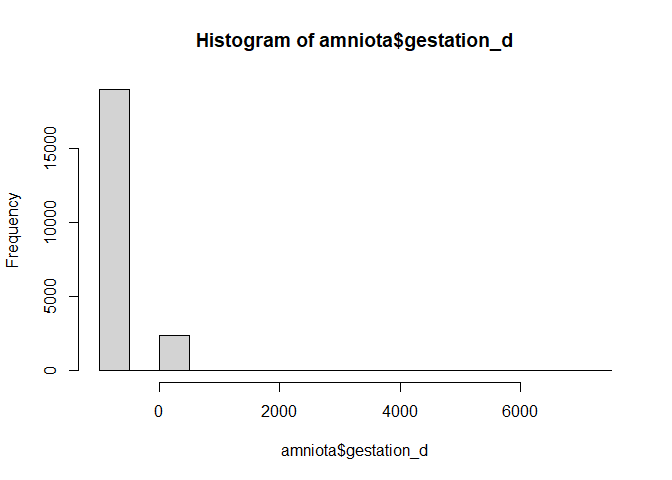

```r
hist(amniota$gestation_d)
```

There are a total of 170566 NAs in the amphibio data, and it makes sense if I look at the histogram of the body mass. The histogram shows that all values in the body mass column are above 0.

```r
amphibio %>%
  miss_var_summary() %>%
  summarize(total_Na=sum(n_miss))
```

```
## # A tibble: 1 × 1
##   total_Na
##      <int>
## 1   170566
```

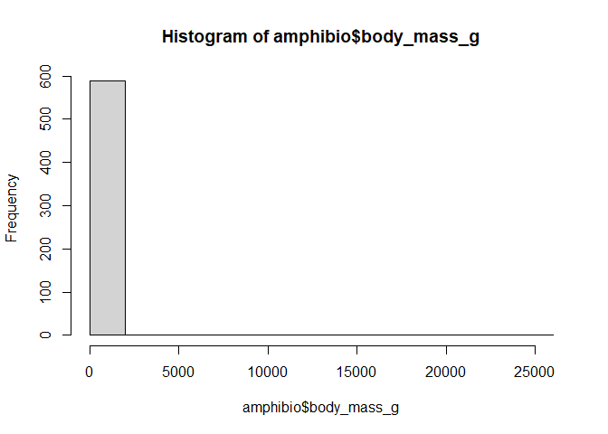

```r
hist(amphibio$body_mass_g)
```

**5. Make any necessary replacements in the data such that all NA’s appear as “NA”.**

```r
amniota_2 <- amniota %>%
  replace_with_na_all(condition = ~.x == -999)
amniota_2
```

```
## # A tibble: 21,322 × 36
##    class order     family genus species subspecies common_name female_maturity_d
##    <chr> <chr>     <chr>  <chr> <chr>        <dbl> <chr>                   <dbl>
##  1 Aves  Accipitr… Accip… Acci… albogu…         NA Pied Gosha…               NA
##  2 Aves  Accipitr… Accip… Acci… badius          NA Shikra                   363.
##  3 Aves  Accipitr… Accip… Acci… bicolor         NA Bicolored …               NA
##  4 Aves  Accipitr… Accip… Acci… brachy…         NA New Britai…               NA
##  5 Aves  Accipitr… Accip… Acci… brevip…         NA Levant Spa…              363.
##  6 Aves  Accipitr… Accip… Acci… castan…         NA Chestnut-f…               NA
##  7 Aves  Accipitr… Accip… Acci… chilen…         NA Chilean Ha…               NA
##  8 Aves  Accipitr… Accip… Acci… chiono…         NA White-brea…              548.
##  9 Aves  Accipitr… Accip… Acci… cirroc…         NA Collared S…               NA
## 10 Aves  Accipitr… Accip… Acci… cooper…         NA Cooper's H…              730
## # ℹ 21,312 more rows
## # ℹ 28 more variables: litter_or_clutch_size_n <dbl>,
## #   litters_or_clutches_per_y <dbl>, adult_body_mass_g <dbl>,
## #   maximum_longevity_y <dbl>, gestation_d <dbl>, weaning_d <dbl>,
## #   birth_or_hatching_weight_g <dbl>, weaning_weight_g <dbl>, egg_mass_g <dbl>,
## #   incubation_d <dbl>, fledging_age_d <dbl>, longevity_y <dbl>,
## #   male_maturity_d <dbl>, inter_litter_or_interbirth_interval_y <dbl>, …
```

**6. Use the package `naniar` to produce a summary, including percentages, of missing data in each column for the `amniota` data.**

```r
amniota_2 %>%
  miss_var_summary() %>%
  arrange(-n_miss)
```

```
## # A tibble: 36 × 3
##    variable                       n_miss pct_miss
##    <chr>                           <int>    <num>
##  1 subspecies                      21322    100
##  2 female_body_mass_at_maturity_g  21318    100.
##  3 female_svl_at_maturity_cm       21120     99.1
##  4 fledging_mass_g                 21111     99.0
##  5 male_svl_cm                     21040     98.7
##  6 no_sex_maturity_d               20860     97.8
##  7 egg_width_mm                    20727     97.2
##  8 egg_length_mm                   20702     97.1
##  9 weaning_weight_g                20258     95.0
## 10 female_svl_cm                   20242     94.9
## # ℹ 26 more rows
```

**7. Use the package `naniar` to produce a summary, including percentages, of missing data in each column for the `amphibio` data.**

```r
amphibio %>%
  miss_var_summary() %>%
  arrange(-n_miss)
```

```
## # A tibble: 38 × 3
##    variable n_miss pct_miss
##    <chr>     <int>    <num>
##  1 fruits     6774    100.
##  2 flowers    6772     99.9
##  3 seeds      6772     99.9
##  4 leaves     6752     99.6
##  5 dry_cold   6735     99.4
##  6 vert       6657     98.2
##  7 obs        6651     98.2
##  8 wet_cold   6625     97.8
##  9 crepu      6608     97.5
## 10 dry_warm   6572     97.0
## # ℹ 28 more rows
```

**8. For the `amniota` data, calculate the number of NAs in the `egg_mass_g` column sorted by taxonomic class; i.e. how many NA’s are present in the `egg_mass_g` column in birds, mammals, and reptiles? Does this results make sense biologically? How do these results affect your interpretation of NA’s?**

Reptiles have 6040 NAs and 92% of the reptile class doesn’t have a data for egg mass, which I think it doesn’t make sense because I thought most reptiles do lay eggs, yet this is still possible if the data didn’t include most reptile species that lay eggs. Mammals have 4953 NAs and there is no data on their egg mass, and this makes sense because mammals don’t lay eggs, so it is impossible to have measurements of egg mass. Birds have 4914 NAs and around half of the species on the data don’t have data for their egg mass, which I don’t think it makes sense biologically because I thought all bird species are oviparous, meaning they reproduce by laying eggs.

```r
amniota_2 %>%
  select(class, egg_mass_g) %>%
  group_by(class) %>%
  miss_var_summary() %>%
  arrange(-n_miss)
```

```
## # A tibble: 3 × 4
## # Groups:   class [3]
##   class    variable   n_miss pct_miss
##   <chr>    <chr>       <int>    <num>
## 1 Reptilia egg_mass_g   6040     92.0
## 2 Mammalia egg_mass_g   4953    100
## 3 Aves     egg_mass_g   4914     50.1
```

**9. The `amphibio` data have variables that classify species as fossorial (burrowing), terrestrial, aquatic, or arboreal.Calculate the number of NA’s in each of these variables. Do you think that the authors intend us to think that there are NA’s in these columns or could they represent something else? Explain.**

When I look at the amphibio data frame, I saw the ones that has data are recorded as “1” or numeric data, so I am guessing that the authors could represent the NAs as “0”, but they recorded the ones without data as “NA”, which also works.

```r
amphibio %>%
  select(fos, aqu, ter, arb) %>%
  miss_var_summary() %>%
  arrange(-n_miss)
```

```
## # A tibble: 4 × 3
##   variable n_miss pct_miss
##   <chr>     <int>    <num>
## 1 fos        6053     89.3
## 2 arb        4347     64.2
## 3 aqu        2810     41.5
## 4 ter        1104     16.3
```

**10. Now that we know how NA’s are represented in the `amniota` data, how would you load the data such that the values which represent NA’s are automatically converted?**

```r
amniota_no_NAs <- read_csv("data/amniota.csv", na=c("-999" )) %>%
  clean_names()
amniota_no_NAs
```

```
## # A tibble: 21,322 × 36
##    class order     family genus species subspecies common_name female_maturity_d
##    <chr> <chr>     <chr>  <chr> <chr>   <lgl>      <chr>                   <dbl>
##  1 Aves  Accipitr… Accip… Acci… albogu… NA         Pied Gosha…               NA
##  2 Aves  Accipitr… Accip… Acci… badius  NA         Shikra                   363.
##  3 Aves  Accipitr… Accip… Acci… bicolor NA         Bicolored …               NA
##  4 Aves  Accipitr… Accip… Acci… brachy… NA         New Britai…               NA
##  5 Aves  Accipitr… Accip… Acci… brevip… NA         Levant Spa…              363.
##  6 Aves  Accipitr… Accip… Acci… castan… NA         Chestnut-f…               NA
##  7 Aves  Accipitr… Accip… Acci… chilen… NA         Chilean Ha…               NA
##  8 Aves  Accipitr… Accip… Acci… chiono… NA         White-brea…              548.
##  9 Aves  Accipitr… Accip… Acci… cirroc… NA         Collared S…               NA
## 10 Aves  Accipitr… Accip… Acci… cooper… NA         Cooper's H…              730
## # ℹ 21,312 more rows
## # ℹ 28 more variables: litter_or_clutch_size_n <dbl>,
## #   litters_or_clutches_per_y <dbl>, adult_body_mass_g <dbl>,
## #   maximum_longevity_y <dbl>, gestation_d <dbl>, weaning_d <dbl>,
## #   birth_or_hatching_weight_g <dbl>, weaning_weight_g <dbl>, egg_mass_g <dbl>,
## #   incubation_d <dbl>, fledging_age_d <dbl>, longevity_y <dbl>,
## #   male_maturity_d <dbl>, inter_litter_or_interbirth_interval_y <dbl>, …
```

**11. Please complete the class project survey at: [BIS 15L Group Project](https://forms.gle/H2j69Z3ZtbLH3efW6)**

## Push your final code to GitHub!

Please be sure that you check the `keep md` file in the knit preferences.